# BELGACEM_BEHANZIN_AP_4204_2022

## Partie 1

#### Introduction

- Librairies utilisées

```r
#install.packages("openxlsx")

library(formattable)
library(rstatix)
library(openxlsx)
```

```r
library(ggplot2)
library(MASS)
library(caret)
```

- Importation des données

On commence par recuperer le jeu de données. On transforme la colonne categorielle en colonne factorielle, ce qui est necessaire pour l’AFD. On va ensuite recuperer le nombre d’observations.

```r
rm(list = ls())
df  <- read.table('VIN_QUALITE.txt', header = T)
df$Quality <- factor(df$Quality)
N <- nrow(df)
head(df)
```

```
##     TP  Sun Heat Rain Quality
## 1 3064 1201   10  361  medium
## 2 3000 1053   11  338     bad
## 3 3155 1133   19  393  medium
## 4 3085  970    4  467     bad
## 5 3245 1258   36  294    good
## 6 3267 1386   35  225    good
```

#### Calcul des inerties :

Ici, nous allons réaliser tous les calculs préliminaires à l’estimation des inerties.

On commence par calculer la moyenne générale :

```r
#Calcul moyenne générale
MoyVar <- colMeans(df[,1:4])
MoyVar
```

```
##         TP        Sun       Heat       Rain
## 3157.88235 1247.32353   18.82353  360.44118
```

On va ensuite calculer les moyennes de variables par classe:

```r
#Moyennes de variables par classe
MoyVarClass <- aggregate(df[, 1:4], list(df$Quality), mean)
MoyVarClass
```

```
##   Group.1       TP      Sun     Heat     Rain
## 1     bad 3037.333 1126.417 12.08333 430.3333
## 2    good 3306.364 1363.636 28.54545 305.0000
## 3  medium 3140.909 1262.909 16.45455 339.6364
```

Pour faciliter nos calculs, on va stocker tous les résultats dans une liste.

```r
#On divise notre base de donnée en fonction du nombres de classes.

Df_C <- split(df[,-5],df$Quality)

#Grace à la fonction lapply(), on va appliquer plusieurs calculs pour les estimations des inerties à notre base de donnée calculé ci-dessous.
#On commence par calculer les Variances par classe, puis on recupere le nombre de observations par classe et la la moyenne de chaque colonne par classe.

L <- lapply(Df_C,
  function(x){
  return(list(
    'CovClass' = var(x)*((nrow(x)-1)/nrow(x)),
    'nrow' = nrow(x),
    'mean' = colMeans(x)
  )
  )
}
)
L
```

```
## $bad
## $bad$CovClass
##             TP        Sun      Heat        Rain
## TP   4407.2222 -919.97222 214.05556   208.13889
## Sun  -919.9722 7162.24306 144.29861   -54.80556
## Heat  214.0556  144.29861  36.40972   -23.44444
## Rain  208.1389  -54.80556 -23.44444 10076.55556
##
## $bad$nrow
## [1] 12
##
## $bad$mean
##         TP        Sun       Heat       Rain
## 3037.33333 1126.41667   12.08333  430.33333
##
##
## $good
## $good$CovClass
##              TP        Sun       Heat       Rain
## TP    7704.0496  3082.5868  532.07438 -2462.8182
## Sun   3082.5868  5862.7769  148.28926 -1214.6364
## Heat   532.0744   148.2893   70.42975  -278.2727
## Rain -2462.8182 -1214.6364 -278.27273  2486.0000
##
## $good$nrow
## [1] 11
##
## $good$mean
##         TP        Sun       Heat       Rain
## 3306.36364 1363.63636   28.54545  305.00000
##
##
## $medium
## $medium$CovClass
##             TP       Sun      Heat      Rain
## TP   9099.1736 3219.6281 534.49587 3448.2397
## Sun  3219.6281 4704.9917 171.13223  829.1488
## Heat  534.4959  171.1322  41.15702  205.7107
## Rain 3448.2397  829.1488 205.71074 2748.5950
##
## $medium$nrow
## [1] 11
##
## $medium$mean
##         TP        Sun       Heat       Rain
## 3140.90909 1262.90909   16.45455  339.63636
```

Nous allons réaliser maintenant le calcul des inerties grâce à la liste calculé précedemment.

```r
#On recupere le nombre de classe.
k <- nlevels(df$Quality)

#Initialisation des variables que nous allons utiliser dans nos calculs.
Inertie_intra <- 0
Inertie_inter <- 0
intra_valeur <- list()
inter_valeur <- list()

#
for (i in 1:k){

  #Calcul de l'inertie intra et on stocke la valeur dans une liste.
  intra_valeur[[i]] <- list(v= L[[i]]$nrow*(L[[i]]$CovClass))
  #Calcul de l'inertie inter et on stocke la valeur dans une liste.
  inter_valeur[[i]] <- list(v= (L[[i]]$nrow*(unlist(L[[i]]$mean)-unlist(MoyVar))%*%t(unlist(L[[i]]$mean)-unlist(MoyVar))))

  #Somme des élements de la liste pour l'inertie intra
  Inertie_intra <- (Inertie_intra + intra_valeur[[i]]$v)
  #Somme des élements de la liste pour l'inertie inter
  Inertie_inter <- (Inertie_inter + inter_valeur[[i]]$v)
}

#On divise l'inertie intra et inter par le nombre d'observations pour obtenir la valeur définitive.
Inertie_intra <- Inertie_intra/N
Inertie_inter <- Inertie_inter/N

#Ici, on calcule l'inertie totale.
Inertie_tot <- Inertie_intra + Inertie_inter

Inertie_intra
```

```
##             TP       Sun      Heat       Rain
## TP   6991.8271 1714.2558 420.61586  392.27362
## Sun  1714.2558 5946.8344 154.27117 -144.05971
## Heat  420.6159  154.2712  48.95209  -31.75045
## Rain  392.2736 -144.0597 -31.75045 5249.97683
```

```r
Inertie_inter
```

```
##              TP        Sun       Heat       Rain
## [1,] 12354.9238 10646.0470  766.80455 -5522.7217
## [2,] 10646.0470  9614.9726  641.52122 -5173.7007
## [3,]   766.8046   641.5212   48.42853  -324.7011
## [4,] -5522.7217 -5173.7007 -324.70111  2858.5638
```

```r
Inertie_tot
```

```
##             TP        Sun       Heat       Rain
## TP   19346.751 12360.3028 1187.42042 -5130.4481
## Sun  12360.303 15561.8071  795.79239 -5317.7604
## Heat  1187.420   795.7924   97.38062  -356.4516
## Rain -5130.448 -5317.7604 -356.45156  8108.5407
```

#### Diagonalisation :

Avant de réaliser la diagonalisation, il nous faut calculer les inerties intra et inter pondéré qui va ensuite nous permettre de calculer le rapport B/W pondéré. De ce rapport, nous pourrons extraire les vecteurs propres qui correspondent aux vecteurs directeurs des axes factoriels.

- Methode de Fisher

On commence par pondérer nos inerties :

```r
# Calcul nous permetttant de pondérer nos inerties.

#Inertie intra pondéré
Inertie_intra_P <- N/(N-k)*Inertie_intra

#Inertie inter pondéré
Inertie_inter_P <- N/(k-1)*Inertie_inter
#remarque : ici, k-1 representent la valeur du nombre d'axes maximale

#Rapport des deux ineries pondéré ( correponds au rapport entre l'effet inter colonne et le signal )
BW <- Inertie_inter_P%*%solve((Inertie_intra_P))
BW
```

```
##              TP        Sun       Heat       Rain
## [1,]  27.604514  21.247501 -73.174170 -18.227340
## [2,]  24.657716  19.660584 -81.773018 -17.072259
## [3,]   1.675324   1.259849  -3.726372  -1.071790
## [4,] -13.158240 -10.768287  50.301994   9.431509
```

- Calcul des vecteurs propres et des valeurs propres

Grâce au rapport calculé dans la partie précédente, on va pouvoir déduire les vecteurs et valeurs propres liés à notre jeu de donnée.

```r
#Initialisation de valeurs qui vont nous servir pendant les calcules

#Valeur du nombre d'axes
nbr_axe <- k-1


#Utilisation de la fonction eigen qui va nous retourner les valeurs propres et les vecteurs propres
dBw <- eigen(BW)


#On stock la partie réelle des vecteurs propres
U <- Re(dBw$vectors)[,1:nbr_axe]
#Remarque : on stock ici 1:nrb_axe colonnes. En effet, le nombre de colonne des vecteurs propres doit être égale au nombres d'axes que nous avons


#normes des vecteurs propres
normes <- sqrt(diag(t(U)%*%Inertie_intra%*%U))


#Vecteur propres normés
VecP <- sweep(U,2,normes,"/")
#fonction sweep permets d'appliquer une procédure à notre m, elle permet aussi de centrer et réduire les colonnes de la matrice.
#On lui renseigne d'abord les données : U
#En deuxième argument, on renseigne si on applique le calcul sur les lignes ou les colonnes : (1 : colonnes) et (2 : lignes)
#En dernier argument, on lui renseigne l'opération que nous voulons utiliser : /
#Remarque : en testant sur les jeux de données VIN_QUALITE et PREMATURE, on remarque que la fonction sweep n'est pas adapter pour tous nos cas, c'est à dire qu'elle renseigne une erreur si le nombre d'axe est plus petit (en l'occurence 1 pour le jeu de donnée PREMATURE)

#C'est pourquoi dans l'implémentation de la fonction, on utilise une autre manière de calculer le vecteur propre normé.

#La boucle nous permets de bien mettre en forme le résultat en fonction de notre nombre axe.
#Elle nous sera plus utilise lors de l'implémentation dans une fonction.
col <- list()
for( i in 1:nbr_axe){
  nomcol <- paste0('Axe_',i)
  col[i] <- nomcol
}
#On renseigne alors le nom des colonnes et des lignes de notre vecteur propre.
colnames(VecP)=col
rownames(VecP)=c("TP","Sun","Heat","Rain")


#Calcul des valeurs propres et mise en forme dans une matrice.
ValP <- matrix(Re(dBw$values)[1:2],2,1)
#On renseigne alors le nom des colonnes et des lignes de notre valeur propre.
colnames(ValP)=c("valeurs_propres")
rownames(ValP)=c("Axe_1","Axe_2")

VecP
```

```
##              Axe_1        Axe_2
## TP   -0.0079538858 -0.010446557
## Sun  -0.0071030886  0.002904653
## Heat -0.0004827976 -0.001166821
## Rain  0.0037897658 -0.006519668
```

```r
ValP
```

```
##       valeurs_propres
## Axe_1       50.822338
## Axe_2        2.147897
```

#### Inference Statistique :

Nous allons construire le test statistique nous permettant de valider le caractère discriminant des axes factoriels.

On réalise alors le calcul de 5 valeurs :

1. La dispersion

```r
#Calcul dispersion
dispersion <- ValP/sum(ValP)*100
```

2. La corrélation canonique

```r
#Calcul corrélation
cor <- sqrt(ValP/(1+ValP))
```

3. Wilks

```r
#Wilks
Wilks <- (1-cor^2)
```

4. Khi Deux

```r
p <- length(df[,-5])

#KHI 2
Kh2 <- -(N - (p+k)/2 -1)*log(Wilks)
```

5. la p-valeur

```r
#pvalue
pvalue <- (1-pchisq(Kh2, p*2))
```

- Résultats

Le resultats est construit avec 6 résultats :

1. Valeurs propres
2. Dispersion
3. Corrélation
4. Wilks
5. Kh Deux
6. P Value

```r
#Création de la matrice contenant les résultats du test statistique
res <- matrix(c(ValP,dispersion,cor,Wilks,Kh2,pvalue),2,6)

#Mise en forme du résultats
colnames(res)=c("valeur propres","% inertie","correlation","Wilks","Kh Deux","p.value")
rownames(res)= c("u1","u2")
res
```

```
##    valeur propres % inertie correlation     Wilks   Kh Deux      p.value
## u1      50.822338 95.945086   0.9903047 0.0192967 116.46073 0.000000e+00
## u2       2.147897  4.054914   0.8260313 0.3176724  33.82867 4.363534e-05
```

## Partie 2

#### Calcul des coordonnées des individus dans le plan factoriel :

Pour réaliser cela, on va effectuer une projection des observations centrées sur les axes factoriels.

On va utiliser la fonction scale() qui permets de centrer les données.

```r
#Calcul de la matrice des observations centrées.
Zij = scale(df[,-5], center = TRUE, scale = FALSE)

#Au début, je recuperais les deux colonnes composant Zij pour constituer la variable Score
# a = Zij%*%VecP[,1]
# b = Zij%*%VecP[,2]

#Par soucis d'automatisation pour l'implémentation de la fonction, j'ai realisé le code suivant :
#Ce code permets de créer la variable score en fonction du nombres d'axe et donc du nombres de classe.
Coord_axe <- list()
for (i in 1:nbr_axe){
  nomcol <- paste0('Axe_',i)
  a <- Zij%*%VecP[,i]
  Coord_axe[nomcol] <- list(a)
}


#Création de la variable Score sans la variable factorielle
Scores_sans_fac <- data.frame(Coord_axe)
Scores_sans_fac
```

```
##          Axe_1       Axe_2
## 1   1.08214744  0.85284573
## 2   2.55480583  1.24032225
## 3   0.95828119 -0.51443817
## 4   2.96054128 -0.72159075
## 5  -1.02884899 -0.46593551
## 6  -2.37404087  0.12705975
## 7   2.83488959 -0.36549457
## 8   2.36356889  0.92784858
## 9   3.18068597 -1.22508213
## 10 -1.47142482 -1.93644030
## 11 -2.21366670 -1.11179804
## 12  0.21534941 -0.25980204
## 13  2.26531528  1.33416067
## 14 -1.67632709 -0.28927415
```

[output cut: 20 more lines]

```r
#Création de la variable Score avec la variable factorielle relative aux classes
Scores <- data.frame(Coord_axe,Quality = df$Quality)
Scores
```

```
##          Axe_1       Axe_2 Quality
## 1   1.08214744  0.85284573  medium
## 2   2.55480583  1.24032225     bad
## 3   0.95828119 -0.51443817  medium
## 4   2.96054128 -0.72159075     bad
## 5  -1.02884899 -0.46593551    good
## 6  -2.37404087  0.12705975    good
## 7   2.83488959 -0.36549457     bad
## 8   2.36356889  0.92784858     bad
## 9   3.18068597 -1.22508213     bad
## 10 -1.47142482 -1.93644030  medium
## 11 -2.21366670 -1.11179804    good
## 12  0.21534941 -0.25980204     bad
## 13  2.26531528  1.33416067     bad
## 14 -1.67632709 -0.28927415    good
```

[output cut: 20 more lines]

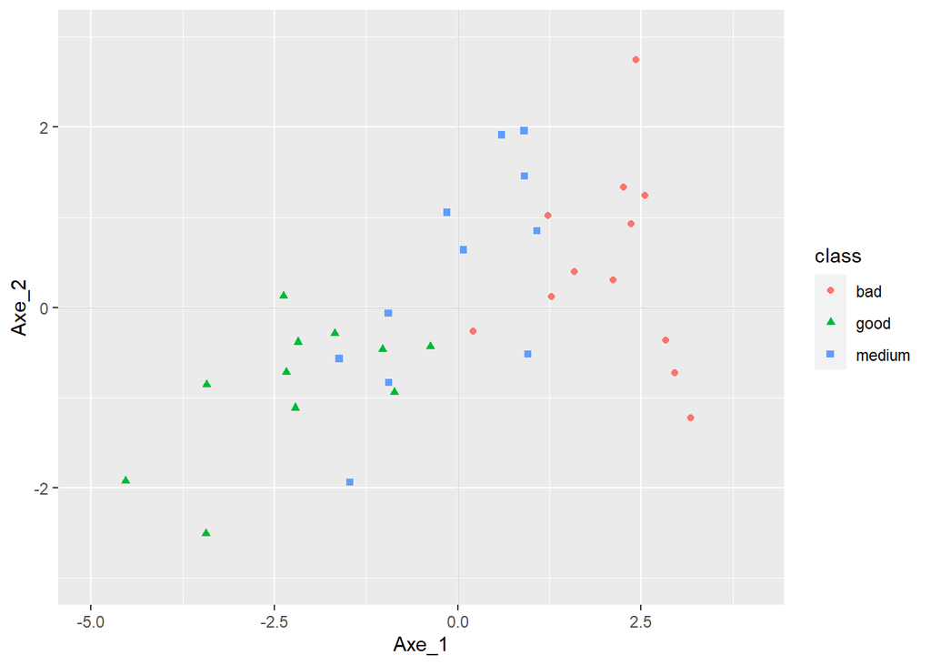

```r
#Permet d'identifier l'index de la colonne de la variable factorielle
id_scores  <- which(!sapply(Scores, is.numeric))

#Permet de renommer la colonne avec la variable factorielle
names(Scores)[id_scores] <- 'class' <- 'class'

#Création du script permettant la représentation des individus dans le plan fctoriel;
gr_ind <- ggplot() +  geom_point(data = Scores  ,aes( x = Axe_1, y = Axe_2, colour = class, shape = class))                                # trace les points
gr_ind <- gr_ind   +  geom_hline(yintercept = 0 , size = 0.1, colour = '#CCCCCC') + geom_vline(xintercept  = 0, size = 0.1,colour = '#CCCCCC') # trace les lignes
gr_ind <- gr_ind   +  xlim(c(-5,4)) + ylim(c(-3,3))  # uniformités des échelles
gr_ind
```

#### Classification :

- Calcul des centres de gravités

On commence par calculer les centres de gravites de chaque classe dans le plan factoriel.

```r
#Calcul des centres de gravités de chaque classe.
G_fac <- aggregate(Scores_sans_fac, list(df$Quality), mean)
G_fac
```

```
##   Group.1       Axe_1      Axe_2
## 1     bad  2.08577435  0.4603207
## 2    good -2.22198634 -0.8631555
## 3  medium -0.05340387  0.3609875
```

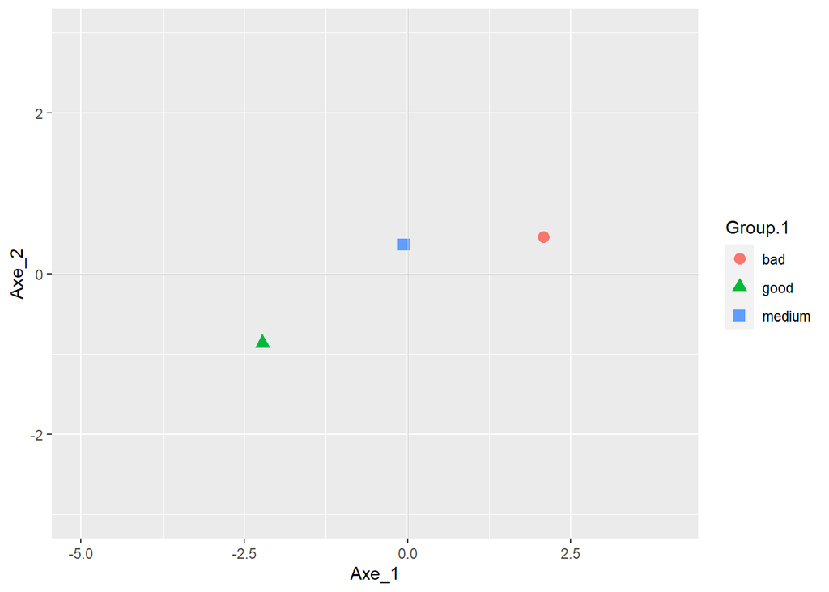

```r
#On reprends le script précedent et on affiche la position des centres de gravité.
 gr_ind <- ggplot() +  geom_point(data = G_fac  ,aes( x = Axe_1, y = Axe_2, colour = Group.1, shape =  Group.1), size = 3)  +  # trace les centres de gravité
                       geom_hline(yintercept = 0 , size = 0.1, colour = '#CCCCCC') + geom_vline(xintercept  = 0, size = 0.1,colour = '#CCCCCC') + # trace les lignes
                       xlim(c(-5,4)) + ylim(c(-3,3))
 gr_ind
```

- Calcul des distances entre les inidividus et les centres de gravité

On calcule la distance entre chaque observation et leur centre de gravité

```r
#on enleve la colonne avec la variable factorielle
value_CG_fac  <-  as.matrix(G_fac[which(sapply(G_fac, is.numeric))])

#Creation de la variable qui va contenir les valeurs
dist <- NULL

for(i in 1:k){
  #col_dist represente la soustraction des scores et des centres de gravités
  col_dist <- Scores[1:ncol(Scores)-1] - matrix(value_CG_fac[i,],ncol = ncol(value_CG_fac) , nrow = N, byrow = T)
  #On applique la fonction qui permet de calculer la distance euclidienne et on les combine
  dist <- cbind(dist,apply(col_dist,1,function(x){return(sqrt(sum(x*x)))}))
}
dist <- as.data.frame(dist)
names(dist) <- G_fac[,1]
dist
```

```
##          bad      good    medium
## 1  1.0776562 3.7231653 1.2374980
## 2  0.9101610 5.2194216 2.7524512
## 3  1.4904347 3.1993289 1.3378627
## 4  1.4704189 5.1844607 3.2024742
## 5  3.2494352 1.2575215 1.2787865
## 6  4.4722494 1.0018217 2.3323975
## 7  1.1149639 5.0813050 2.9782571
## 8  0.5438310 4.9229069 2.4825569
## 9  2.0098294 5.4147815 3.6020763
## 10 4.2893040 1.3096881 2.6998070
## 11 4.5778544 0.2487817 2.6145425
## 12 2.0042620 2.5109044 0.6764672
## 13 0.8920938 4.9964061 2.5146619
## 14 3.8360526 0.7918862 1.7483478
```

[output cut: 20 more lines]

On va maintenant s’interesser à réaliser le tableau comparant les affectations liées aux prédictions et l’appartenance réelle de l’observation au groupe.

Tout d’abord, on réalise la prédiction d’appartenance. Pour cela, on s’aide des distances calculées précedemment.

Pour determiner les prédictions, on regarde pour chaque ligne la distance la plus faible et on retourne l’indice de la colonne qui represente la classe.

```r
#Calcul des prédictions d'appartenance
quality_pred <- as.factor(apply(dist, 1, which.min))

#Tableau de comparaison entre l'appartenance réelle et la prédiction
pred_class <- data.frame(TrueValue= df$Quality,Prediction=levels(df$Quality)[quality_pred])
pred_class$Prediction<- as.factor(pred_class$Prediction)
pred_class
```

```
##    TrueValue Prediction
## 1     medium        bad
## 2        bad        bad
## 3     medium     medium
## 4        bad        bad
## 5       good       good
## 6       good       good
## 7        bad        bad
## 8        bad        bad
## 9        bad        bad
## 10    medium       good
## 11      good       good
## 12       bad     medium
## 13       bad        bad
## 14      good       good
```

[output cut: 20 more lines]

#### Qualité de la prédiction :

Pour cela, on utilise la fonction confusionMatrix du package caret.

```r
confusionMatrix(pred_class$Prediction, pred_class$TrueValue)
```

```
## Confusion Matrix and Statistics
##
##           Reference
## Prediction bad good medium
##     bad     11    0      1
##     good     0   10      3
##     medium   1    1      7
##
## Overall Statistics
##
##                Accuracy : 0.8235
##                  95% CI : (0.6547, 0.9324)
##     No Information Rate : 0.3529
##     P-Value [Acc > NIR] : 2.403e-08
##
##                   Kappa : 0.7351
##
##  Mcnemar's Test P-Value : NA
##
## Statistics by Class:
##
##                      Class: bad Class: good Class: medium
## Sensitivity              0.9167      0.9091        0.6364
## Specificity              0.9545      0.8696        0.9130
## Pos Pred Value           0.9167      0.7692        0.7778
## Neg Pred Value           0.9545      0.9524        0.8400
## Prevalence               0.3529      0.3235        0.3235
## Detection Rate           0.3235      0.2941        0.2059
## Detection Prevalence     0.3529      0.3824        0.2647
## Balanced Accuracy        0.9356      0.8893        0.7747
```

On affiche ensuite le graphique des inidividus mal classés dans le plan factoriel.

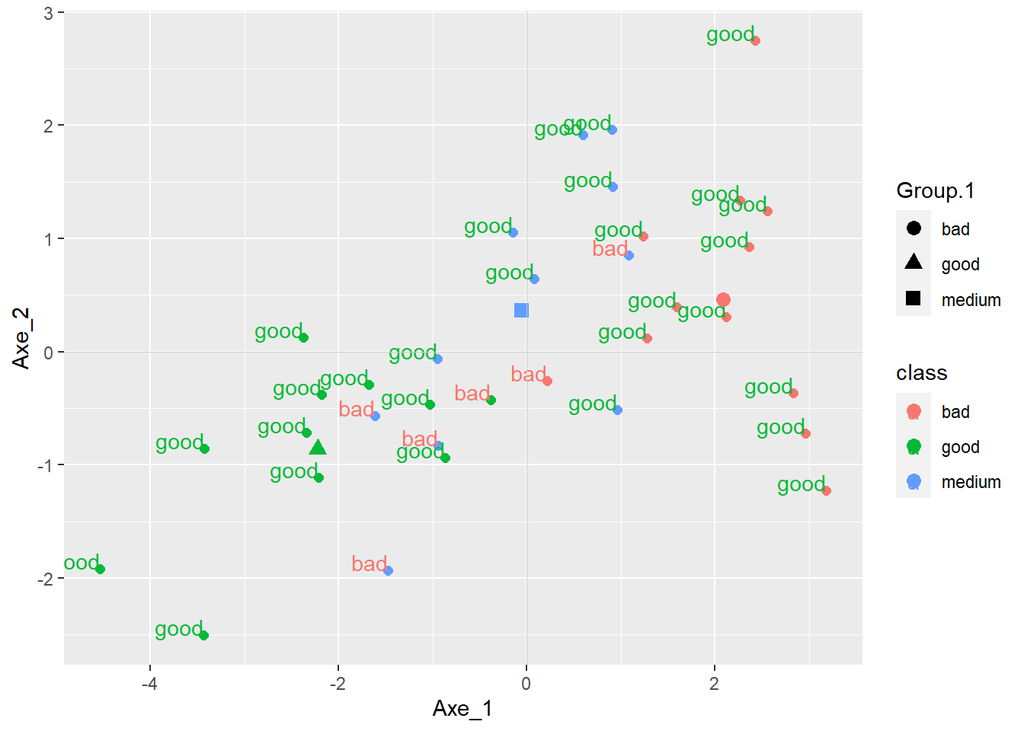

```r
Scores <- cbind(Scores, good_class = ifelse(pred_class$Prediction ==  pred_class$TrueValue, 'good','bad') )

gr_ind <- ggplot() + geom_point(data = Scores, aes(x = Axe_1, y = Axe_2, colour = class), size = 2)    +
                     geom_text (data = Scores, aes(x = Axe_1, y = Axe_2, label = good_class, colour = good_class), hjust = 1, vjust = 0 ) +
                     geom_point(data = G_fac,  aes(x = Axe_1, y = Axe_2, colour = Group.1, shape =  Group.1), size = 3)  +  # trace les centres de gravité
                     geom_hline(yintercept = 0 , size = 0.1, colour = '#CCCCCC') + geom_vline(xintercept  = 0, size = 0.1,colour = '#CCCCCC')
gr_ind
```

## Partie 3 :

#### Classification Bayésienne

L’objectif de cette partie est de comparer la classification obtenue à l’aide d’une autre méthode : l’analyse linéaire disciminante. On va utiliser la fonction lda du package MASS.

Nous allons utiliser 3 arguments de celle-ci :

1- le premier est celui qui renseigne la variable factorielle et les variables explicatives. Dans notres cas, on mets Quality ~. , le point veut simplement dire que l’on veut prendres toutes les variables restantes.

2- le second est data qui permets de renseigner la data frame

3- le troisième est CV qui permets d’avoir des résultats plus fiable. Elle permets de réaliser une validation croisée.

```r
model <- lda(Quality ~., data = df, CV=T)
model
```

```
## $class
##  [1] medium bad    bad    bad    medium good   bad    bad    bad    good
## [11] good   medium bad    medium medium medium medium bad    medium good
## [21] medium good   medium good   medium good   good   bad    good   medium
## [31] bad    medium medium bad
## Levels: bad good medium
##
## $posterior
##             bad         good       medium
## 1  3.838016e-01 6.812376e-03 6.093860e-01
## 2  9.447086e-01 6.944033e-05 5.522200e-02
## 3  8.226608e-01 7.585216e-03 1.697540e-01
## 4  9.759279e-01 1.042323e-05 2.406166e-02
## 5  1.349160e-01 2.508386e-01 6.142454e-01
## 6  1.762093e-04 8.973196e-01 1.025042e-01
## 7  9.917285e-01 1.033894e-05 8.261126e-03
## 8  9.727593e-01 2.784507e-05 2.721287e-02
## 9  9.999514e-01 4.118722e-09 4.860691e-05
## 10 4.920460e-03 9.082393e-01 8.684019e-02
## 11 1.639763e-04 8.775669e-01 1.222691e-01
## 12 1.472910e-01 1.569921e-01 6.957169e-01
## 13 8.709907e-01 2.204869e-04 1.287888e-01
## 14 1.992703e-03 4.724818e-01 5.255255e-01
## 15 4.556871e-01 9.996132e-03 5.343168e-01
## 16 9.517114e-02 1.623448e-02 8.885944e-01
## 17 2.318892e-02 7.746162e-02 8.993495e-01
## 18 9.765067e-01 4.617546e-05 2.344714e-02
## 19 1.883001e-02 4.616958e-01 5.194742e-01
## 20 6.343872e-05 8.875888e-01 1.123477e-01
## 21 3.840692e-03 4.269425e-01 5.692168e-01
## 22 2.157267e-07 9.792815e-01 2.071830e-02
## 23 2.469897e-01 1.472016e-02 7.382901e-01
## 24 1.083504e-06 9.971666e-01 2.832334e-03
## 25 3.724372e-02 6.902944e-02 8.937268e-01
## 26 3.445390e-09 9.995112e-01 4.888246e-04
## 27 1.497315e-03 7.871744e-01 2.113283e-01
## 28 8.597051e-01 8.258015e-04 1.394691e-01
## 29 1.655953e-04 8.321700e-01 1.676644e-01
## 30 4.590881e-02 1.249803e-01 8.291108e-01
## 31 6.821761e-01 1.763703e-04 3.176475e-01
```

[output cut: 21 more lines]

```
## attr(,"response")
## [1] 1
## attr(,".Environment")
## <environment: R_GlobalEnv>
## attr(,"predvars")
## list(Quality, TP, Sun, Heat, Rain)
## attr(,"dataClasses")
##   Quality        TP       Sun      Heat      Rain
##  "factor" "numeric" "numeric" "numeric" "numeric"
##
## $call
## lda(formula = Quality ~ ., data = df, CV = T)
##
## $xlevels
## named list()
```

On crée ensuite une matrice de confusion pour déterminer la qualité de la prédiction.

```r
confusionMatrix(df$Quality, model$class)
```

```
## Confusion Matrix and Statistics
##
##           Reference
## Prediction bad good medium
##     bad     10    0      2
##     good     0    7      4
##     medium   1    2      8
##
## Overall Statistics
##
##                Accuracy : 0.7353
##                  95% CI : (0.5564, 0.8712)
##     No Information Rate : 0.4118
##     P-Value [Acc > NIR] : 0.0001339
##
##                   Kappa : 0.6031
##
##  Mcnemar's Test P-Value : NA
##
## Statistics by Class:
##
##                      Class: bad Class: good Class: medium
## Sensitivity              0.9091      0.7778        0.5714
## Specificity              0.9130      0.8400        0.8500
## Pos Pred Value           0.8333      0.6364        0.7273
## Neg Pred Value           0.9545      0.9130        0.7391
## Prevalence               0.3235      0.2647        0.4118
## Detection Rate           0.2941      0.2059        0.2353
## Detection Prevalence     0.3529      0.3235        0.3235
## Balanced Accuracy        0.9111      0.8089        0.7107
```

- Interprétation :

En comparant nos deux classification grâce à la fonction confusionMatrix, on peut en conclure que pour notre jeu de donnée VIN_QUALITE, la précision est meilleure avec notre AFD que avec la LDA.

## Partie 4:

Dans cette dernière partie, on va s’interesser à l’encapsulation de tous les calculs que nous avons fait dans une fonction afin de automatiser les calculs.

Nous allons travailler sur le fichier prematures.xlsx.

La fonction va devoir nous retourner :

- la Covariance
- la moyenne par colonne
- le nombre d’observation par classe
- les inerties intra, inter et totale.
- le rapport B/W
- les valeurs propres
- les vecteurs propres
- le test statistique
- les coordonnées des individus dans le plan factoriel (Scores)
- les centres de gravites
- la distance entre les observations et les centres de gravités
- la prediction
- la matrice de confusion
- la comparaison avec la classification LDA
- les graphiques

```r
rm(list = ls())

AFD_class <- function(dfw)
{
  #-> détection automatique des variables numériques
  id_num <- which(sapply(dfw, is.numeric))
  X <- dfw[,id_num]

  #-> .. on cherche la variable NON numérique ..
  id_string  <- which(!sapply(dfw, is.numeric))

  #-> pour faciliter et uniformiser les recherches des classes, on renomme cette variable
  names(dfw)[id_string] <- 'Quality'

  # On transforme la colonne categorielle en colonne factorielle
  dfw$Quality <- as.factor(dfw$Quality)

  ###Partie 1

  ## Calcul des Covariance, du nombre d'observations et des moyennes par classe

  #On divise notre base de donnée, en excluant la colonne factorielle, en fonction du nombres de classes.
  Df_C <- split(dfw[,-id_string],dfw$Quality)

  #Grace à la fonction lapply(), on va appliquer plusieurs calculs pour les estimations des inerties à notre base de donnée calculé      ci-dessous.
  #On commence par calculer les Variances par classe, puis on recupere le nombre de ligne par classe et la la moyenne de chaque colonne   par classe.
  L <- lapply(Df_C,
              function(x){
                return(list(
                  'CovClass' = var(x)*((nrow(x)-1)/nrow(x)),
                  'nrow' = nrow(x),
                  'mean' =  colMeans(x))
                )
              }
  )


  #Calcul moyenne générale en excluant la colonne factorielle
  MoyVar <- colMeans(dfw[,-id_string])


  ## Calcul des inerties inter, intra et totale


  #On recupere le nombre de niveau de notre jeu de donnée
  k <- nlevels(dfw$Quality)

  #Initialisation des variables que nous allons utiliser dans nos calculs.
  Inertie_intra <- 0
  Inertie_inter <- 0
  intra_valeur <- list()
  inter_valeur <- list()


  for (i in 1:k){

    #Calcul de l'inertie intra et on stocke la valeur dans une liste.
    intra_valeur[[i]] <- list(v= L[[i]]$nrow*(L[[i]]$CovClass))
    #Calcul de l'inertie inter et on stocke la valeur dans une liste.
    inter_valeur[[i]] <- list(v= (L[[i]]$nrow*(unlist(L[[i]]$mean)-unlist(MoyVar))%*%t(unlist(L[[i]]$mean)-unlist(MoyVar))))


    #Somme des élements de la liste pour l'inertie intra
    Inertie_intra <- (Inertie_intra + intra_valeur[[i]]$v)
    #Somme des élements de la liste pour l'inertie inter
    Inertie_inter <- (Inertie_inter + inter_valeur[[i]]$v)

  }

  #On recupere le nombre dobservation de notre jeu de donnéeS
  N <- nrow(dfw)

  #On divise l'inertie intra et inter par le nombre d'observations pour obtenir la valeur définitive.
  Inertie_intra <- Inertie_intra/N
  Inertie_inter <- Inertie_inter/N

  #Calcul inertie totale
  Inertie_tot <- Inertie_intra + Inertie_inter


  ## Calcul du rapport


  #Inertie intra pondéré
  Inertie_intra_P <- N/(N-k)*Inertie_intra
  #Inertie inter pondéré
  Inertie_inter_P <- N/(k-1)*Inertie_inter
  #remarque : ici, k-1 representent la valeur du nombre d'axes maximale

  #Calcul du rapport entres les deux inerties pondérées
  BW <- Inertie_inter_P%*%solve((Inertie_intra_P))


  ## Calcul des Valeurs propres et Vecteurs propres


  #Valeur du nombre d'axes
  nbr_axe <- k-1

  #Utilisation de la fonction eigen qui va nous retourner les valeurs propres et les vecteurs propres
  dBw <- eigen(BW)

  #On stock la partie réelle des vecteurs propres
  U <- Re(dBw$vectors)[,1:nbr_axe]
  #Remarque : on stock ici 1:nrb_axe colonnes. En effet, le nombre de colonne des vecteurs propres doit être égale au nombres d'axes     que nous avons


  #normes des vecteurs propres
  normes <- sqrt(diag(t(U)%*%Inertie_intra%*%U))

  #Calcul des vecteurs propres normés
  VecP<- t(t(U)/normes)
  #Remarque : comme expliqué dans le partie 2, on utilise un autre calcul qui permet de simplifier le calcul des vecteurs normés dans    l'implémentation de la fonction.

  #On va mettre en forme le résultat en fonction des noms des colonnes et des nombres d'axes.
  #permets de recuperer les noms des colonnes (sans la colonne factorielle) pour pouvoir les mettre dans les lignes du tableau
  coldata <- names(dfw[,-id_string])
  rownames(VecP)<-  coldata

  #Boucle permettant de mettre le nombre d'axe dans le nom des colonnes
  col <- list()
  for( i in 1:nbr_axe){
    nomcol <- paste0('Axe_',i)
    col[i] <- nomcol
  }
  colnames(VecP)<- col

  #Calcul des valeurs propres et mise en forme dans une matrice en fonction du nombres d'axe.
  ValP <- matrix(Re(dBw$values)[1:nbr_axe],nbr_axe,1)
  colnames(ValP)<-c("valeurs_propres")
  rownames(ValP)<- col


  ##Calcul du test statistique


  #nombre de colonne quantitatives
  p <- length(dfw[,-id_string])

  #Calcul dispersion
  dispersion  <- ValP/sum(ValP)*100

  #Calcul de la corrélation
  cor <- sqrt(ValP/(1+ValP))

  #Calcul du Wilks
  Wilks <- (1-cor^2)

  #Calcul du Khi 2
  Kh2 <- -(N - (p+k)/2 -1)*log(Wilks)

  #Calcul de la pvalue
  pvalue <- (1-pchisq(Kh2, p*2))

  #Création de la matrice contenant les résultats du test statistique
  res <- matrix(c(ValP,dispersion ,cor,Wilks,Kh2,pvalue),nbr_axe,6)

  #Mise en forme des résultats en fonction du nombres d'axes.
  colnames(res)<- c("valeur propres","% inertie","correlation","Wilks","Kh Deux","p.value")
  u <- list()
  for( i in 1:nbr_axe){
    nomcol <- paste0('u',i)
    u[i] <- nomcol
  }
  rownames(res)<-  u



  ###Partie 2


  ##Calcul des coordonnées des individus


  #Calcul de la matrice des observations centrées.
  Zij <- scale(dfw[,-id_string], center = TRUE, scale = FALSE)

  #permets de récuperer tous les colonnes de la matrice des observations centrées et de mettre en forme le résultats en fonction du      nombre d'axes
  Coord_axe <- list()
  for (i in 1:nbr_axe){
    nomcol <- paste0('Axe_',i)
    a <- Zij%*%VecP[,i]
    Coord_axe[nomcol] <- list(a)
  }

  #Création de la variable Score sans la variable factorielle(correponds au coordonnées des individus dans le plan factoriel)
  Scores_sans_fac <- data.frame(Coord_axe)
  #Création de la variable Score avec la variable factorielle relative aux classes
  Scores <- data.frame(Coord_axe,Quality = dfw$Quality)


  ##Calcul des centres de gravités


  Centre_Gravite_fac <- aggregate(Scores_sans_fac, list(dfw$Quality), mean)


  ##Calcul des distances entre observations et centres de gravités



  #on enleve la colonne avec la variable factorielle
  value_CG_fac  <-  as.matrix(Centre_Gravite_fac[which(sapply(Centre_Gravite_fac, is.numeric))])

  #Creation de la variable qui va contenir les valeurs
  dist <- NULL

  for(i in 1:k){
    #col_dist represente la soustraction des scores et des centres de gravités
    col_dist <- Scores[1:ncol(Scores)-1] - matrix(value_CG_fac[i,],ncol = ncol(value_CG_fac) , nrow = N, byrow = T)
    #On applique la fonction qui permet de calculer la distance euclidienne et on les combine
    dist <- cbind(dist,apply(col_dist,1,function(x){return(sqrt(sum(x*x)))}))
  }
  dist <- as.data.frame(dist)
  names(dist) <- Centre_Gravite_fac[,1]



  ## Calcul des prédictions d'appartenance et matrice de confusion

  #retourne vecteur avec l"indice de la colonne avec la distance la plus petite
  quality_pred <- factor(apply(dist, 1, which.min))

  #Tableau de comparaison entre l'appartenance réelle et la prédiction
  pred_class <- data.frame(TrueValue= dfw$Quality,Prediction=levels(dfw$Quality)[quality_pred])
  #on mets la colonne en colonne factorielle pour son utilisation dans la matrice de confusion
  pred_class$Prediction<- as.factor(pred_class$Prediction)

  #Calcul matrice de confusion
  Matrice_confusion <- confusionMatrix(pred_class$Prediction, pred_class$TrueValue)

  #Création modèle selon la classification lda
  model <- lda(Quality ~., data = dfw, CV=T)

  #Matrice confusion de ce model
  Matrice_confusion_lda <- confusionMatrix(dfw$Quality, model$class)


  ##Affichage des résultats

  #Création d'une boucle qui permets d'afficher les graphiques si cela est possible.
  #Si le nombre d'axe est de 2, alors on pourra afficher un graphique en 2D, sinon on retourne une liste dans le graphique.
  #Ce n'est pas interessant de faire un graphique en 1D
  if(nbr_axe != 2){
    ret   <- list(liste = L
                  ,Inertie_intra = Inertie_intra, Inertie_inter = Inertie_inter, Inertie_tot = Inertie_tot,rapp = BW
                  ,VecPropre = VecP ,ValPropre= ValP
                  ,InfStat = res
                  ,Score = Scores
                  ,Centre_Gravite_fac = Centre_Gravite_fac
                  ,distance = dist
                  ,prediction = pred_class
                  ,Matrice_confusion = Matrice_confusion
                  ,Comparaison_qualité_lda = Matrice_confusion_lda
    )
  }else{

    Scores <- cbind(Scores, good_class = ifelse(pred_class$Prediction ==  pred_class$TrueValue, 'good','bad') )

    gr_ind <- ggplot() +
       geom_point(data = Scores, aes(x = Axe_1, y = Axe_2, colour = Quality), size = 2)  +
       geom_text (data = Scores, aes(x = Axe_1, y = Axe_2, label = good_class, colour = good_class), hjust = 1, vjust = 0 ) +
       geom_point(data = Centre_Gravite_fac,  aes(x = Axe_1, y = Axe_2, colour = Group.1, shape =  Group.1), size = 3)+
      geom_hline(yintercept = 0 , size = 0.1, colour = '#CCCCCC') + geom_vline(xintercept  = 0, size = 0.1,colour = '#CCCCCC')

    ret   <- list(liste = L
                  ,Iw = Inertie_intra, Ib = Inertie_inter, Itot = Inertie_tot,rapp = BW
                  ,VecPropre = VecP ,ValPropre= ValP
                  ,InfStat = res
                  ,Score = Scores
                  ,Centre_Gravite_fac = Centre_Gravite_fac
                  ,distance = dist
                  ,prediction = pred_class
                  ,Matrice_confusion = Matrice_confusion
                  ,Comparaison_qualité_lda = Matrice_confusion_lda
                  ,graph = gr_ind
    )
  }

  return(ret)

}
```

```r
df_exemple<- read.xlsx(xlsxFile="prematures.xlsx")
df  <- read.table('VIN_QUALITE.txt', header = T)

result <- AFD_class(df_exemple)
print(result)
```

```
## $liste
## $liste$negatif
## $liste$negatif$CovClass
##                GEST       DILATE      EFFACE       CONSIS        CONTR
## GEST     8.99817898  0.234781478  10.5231530  0.495577523 -0.220083247
## DILATE   0.23478148  0.608415713   3.1376171  0.155437045 -0.018990635
## EFFACE  10.52315297  3.137617066 677.1883455  6.566597294 -0.318158169
## CONSIS   0.49557752  0.155437045   6.5665973  0.565296566 -0.019510926
## CONTR   -0.22008325 -0.018990635  -0.3181582 -0.019510926  0.076482830
## MEMBRAN  0.13696670  0.008129553   1.0517690  0.004292404 -0.022632674
## AGE     -0.81152445 -0.102302289  -3.6664932 -0.211628512 -0.011706556
## STRAT    2.11745578  0.042078564   2.3655047  0.091701353 -0.054630593
## GRAVID  -0.52159209  0.159989594   3.2388137 -0.021331946  0.065556712
## PARIT   -0.58584807  0.091311134   0.2643080 -0.070239334  0.030176899
## DIAB     0.07010926 -0.035054631  -1.3228408 -0.079734651 -0.010665973
```

[output cut: 1538 more lines]

- Interprétation : Pour le jeu de donnée premature.xlsx, on remarque que la prévision est meilleure avec la LDA que l’AFD.